# Yelp – Analiza sentymentu recenzji

## 1 Wprowadzenie

Serwisy takie jak Yelp umożliwiają użytkownikom ocenę biznesów przy pomocy **ocen gwiazdkowych (1–5)** oraz **opisowych recenzji tekstowych**. Ocena gwiazdkowa jest syntetycznym, liczbowym podsumowaniem doświadczenia użytkownika, natomiast tekst recenzji zawiera bogatszy kontekst emocjonalny i opisowy.

W ramach tego projektu analizowana jest **zgodność pomiędzy oceną gwiazdkową a sentymentem treści recenzji**, wyznaczanym automatycznie przy użyciu modeli NLP udostępnionych przez platformę Hugging Face.

### 1.1 Problem badawczy

Czy sentyment wyrażony w treści recenzji tekstowej jest zgodny z oceną gwiazdkową nadaną przez użytkownika?

### 1.2 Hipoteza

- wraz ze wzrostem liczby gwiazdek rośnie udział recenzji o sentymencie pozytywnym,
- wraz ze spadkiem liczby gwiazdek rośnie udział recenzji o sentymencie negatywnym,
- recenzje 3-gwiazdkowe mają największy udział sentymentu neutralnego (najbardziej “mieszane”).

## 2 Dane

W analizie wykorzystano publicznie dostępny zbiór danych **Yelp Open Dataset**, obejmujący: - recenzje użytkowników (ocena gwiazdkowa, treść tekstowa), - metadane dotyczące biznesów (kategorie, lokalizacja, średnia ocena).

Ze względu na ograniczenia czasowe i kosztowe API, analiza sentymentu wykonywana jest na **losowej próbce recenzji** pobranej z pełnego zbioru danych.

## 3 Metodologia

1. Zbiór recenzji Yelp zostaje wczytany i poddany wstępnemu przetwarzaniu.
2. Dla losowo wybranej próby* recenzji obliczany jest sentyment tekstu przy użyciu wybranego modelu NLP (Hugging Face Inference API).
3. Każdej recenzji przypisywana jest etykieta sentymentu (NEGATIVE / NEUTRAL / POSITIVE).
4. Analizowany jest rozkład sentymentu w zależności od liczby gwiazdek przyznanych przez użytkowników.
5. Wyniki prezentowane są w formie wykresów i tabel agregujących dane.

Analiza ma charakter **eksploracyjny** i służy weryfikacji spójności pomiędzy oceną liczbową a emocjonalnym wydźwiękiem treści recenzji.

## 4 Konfiguracja

```r
REVIEW_PATH   <- "data/yelp_academic_dataset_review.json"
BUSINESS_PATH <- "data/yelp_academic_dataset_business.json"

NROWS <- 50000
ANALYZE_LIMIT <- 100
RANDOM_STATE <- 420

MODEL_NAME <- "cardiffnlp/twitter-roberta-base-sentiment-latest"

HF_TOKEN <- "HF_TOKEN"
```

## 5 Wczytanie danych (JSONL)

```r
read_yelp_jsonl <- function(path, nrows) {
  con <- file(path, open = "r", encoding = "UTF-8")
  on.exit(close(con), add = TRUE)

  lines <- readLines(con, n = nrows, warn = FALSE)

  df <- jsonlite::fromJSON(paste0("[", paste(lines, collapse = ","), "]"))
  as_tibble(df)
}

reviews_raw  <- read_yelp_jsonl(REVIEW_PATH, NROWS)
business_raw <- read_yelp_jsonl(BUSINESS_PATH, NROWS)

reviews <- reviews_raw %>%
  select(review_id, user_id, business_id, stars, text)

business <- business_raw %>%
  select(business_id, name, address, city, state, postal_code,
         latitude, longitude, stars, review_count, is_open, categories)

glimpse(reviews)
```

```
## Rows: 50,000
## Columns: 5
## $ review_id   <chr> "KU_O5udG6zpxOg-VcAEodg", "BiTunyQ73aT9WBnpR9DZGw", "saUsX…
## $ user_id     <chr> "mh_-eMZ6K5RLWhZyISBhwA", "OyoGAe7OKpv6SyGZT5g77Q", "8g_iM…
## $ business_id <chr> "XQfwVwDr-v0ZS3_CbbE5Xw", "7ATYjTIgM3jUlt4UM3IypQ", "YjUWP…
## $ stars       <dbl> 3, 5, 3, 5, 4, 1, 5, 5, 3, 3, 5, 4, 4, 4, 4, 5, 5, 4, 5, 5…
## $ text        <chr> "If you decide to eat here, just be aware it is going to t…
```

```r
glimpse(business)
```

```
## Rows: 50,000
## Columns: 12
## $ business_id  <chr> "Pns2l4eNsfO8kk83dixA6A", "mpf3x-BjTdTEA3yCZrAYPw", "tUFr…
## $ name         <chr> "Abby Rappoport, LAC, CMQ", "The UPS Store", "Target", "S…
## $ address      <chr> "1616 Chapala St, Ste 2", "87 Grasso Plaza Shopping Cente…
## $ city         <chr> "Santa Barbara", "Affton", "Tucson", "Philadelphia", "Gre…
## $ state        <chr> "CA", "MO", "AZ", "PA", "PA", "TN", "MO", "FL", "MO", "TN…
## $ postal_code  <chr> "93101", "63123", "85711", "19107", "18054", "37015", "63…
## $ latitude     <dbl> 34.42668, 38.55113, 32.22324, 39.95551, 40.33818, 36.2695…
## $ longitude    <dbl> -119.71120, -90.33570, -110.88045, -75.15556, -75.47166, …
## $ stars        <dbl> 5.0, 3.0, 3.5, 4.0, 4.5, 2.0, 2.5, 3.5, 3.0, 1.5, 3.5, 4.…
## $ review_count <int> 7, 15, 22, 80, 13, 6, 13, 5, 19, 10, 6, 10, 28, 10, 100, …
## $ is_open      <int> 0, 1, 0, 1, 1, 1, 1, 1, 0, 1, 1, 1, 1, 1, 0, 1, 1, 1, 1, …
## $ categories   <chr> "Doctors, Traditional Chinese Medicine, Naturopathic/Holi…
```

## 6 Reviews – podgląd i statystyki

```r
reviews_preview <- reviews %>%
  mutate(text = str_trunc(text, width = 200)) %>%
  head(5)

kable(reviews_preview, escape = TRUE)
```

| review_id | user_id | business_id | stars | text |
| --- | --- | --- | --- | --- |
| KU_O5udG6zpxOg-VcAEodg | mh_-eMZ6K5RLWhZyISBhwA | XQfwVwDr-v0ZS3_CbbE5Xw | 3 | If you decide to eat here, just be aware it is going to take about 2 hours from beginning to end. We have tried it multiple times, because I want to like it! I have been to it’s other locations in … |
| BiTunyQ73aT9WBnpR9DZGw | OyoGAe7OKpv6SyGZT5g77Q | 7ATYjTIgM3jUlt4UM3IypQ | 5 | I’ve taken a lot of spin classes over the years, and nothing compares to the classes at Body Cycle. From the nice, clean space and amazing bikes, to the welcoming and motivating instructors, every … |
| saUsX_uimxRlCVr67Z4Jig | 8g_iMtfSiwikVnbP2etR0A | YjUWPpI6HXG530lwP-fb2A | 3 | Family diner. Had the buffet. Eclectic assortment: a large chicken leg, fried jalapeño, tamale, two rolled grape leaves, fresh melon. All good. Lots of Mexican choices there. Also has a menu with b… |
| AqPFMleE6RsU23_auESxiA | _7bHUi9Uuf5__HHc_Q8guQ | kxX2SOes4o-D3ZQBkiMRfA | 5 | Wow! Yummy, different, delicious. Our favorite is the lamb curry and korma. With 10 different kinds of naan!!! Don’t let the outside deter you (because we almost changed our minds)…go in an… |
| Sx8TMOWLNuJBWer-0pcmoA | bcjbaE6dDog4jkNY91ncLQ | e4Vwtrqf-wpJfwesgvdgxQ | 4 | Cute interior and owner (?) gave us tour of upcoming patio/rooftop area which will be great on beautiful days like today. Cheese curds were very good and very filling. Really like that sandwiches c… |

```r
reviews_metrics <- tibble::tibble(
  `Liczba recenzji` = nrow(reviews),
  `Średnia ocena gwiazdkowa` = round(mean(reviews$stars, na.rm = TRUE), 2),
  `Liczba unikalnych biznesów` = n_distinct(reviews$business_id),
  `Liczba unikalnych recenzentów` = n_distinct(reviews$user_id)
)

reviews_metrics |> kable()
```

| Liczba recenzji | Średnia ocena gwiazdkowa | Liczba unikalnych biznesów | Liczba unikalnych recenzentów |
| --- | --- | --- | --- |
| 50000 | 3.85 | 8026 | 42936 |

## 7 Business – podgląd i statystyki

```r
head(business, 5) |> kable()
```

| business_id | name | address | city | state | postal_code | latitude | longitude | stars | review_count | is_open | categories |
| --- | --- | --- | --- | --- | --- | --- | --- | --- | --- | --- | --- |
| Pns2l4eNsfO8kk83dixA6A | Abby Rappoport, LAC, CMQ | 1616 Chapala St, Ste 2 | Santa Barbara | CA | 93101 | 34.42668 | -119.71120 | 5.0 | 7 | 0 | Doctors, Traditional Chinese Medicine, Naturopathic/Holistic, Acupuncture, Health & Medical, Nutritionists |
| mpf3x-BjTdTEA3yCZrAYPw | The UPS Store | 87 Grasso Plaza Shopping Center | Affton | MO | 63123 | 38.55113 | -90.33570 | 3.0 | 15 | 1 | Shipping Centers, Local Services, Notaries, Mailbox Centers, Printing Services |
| tUFrWirKiKi_TAnsVWINQQ | Target | 5255 E Broadway Blvd | Tucson | AZ | 85711 | 32.22324 | -110.88045 | 3.5 | 22 | 0 | Department Stores, Shopping, Fashion, Home & Garden, Electronics, Furniture Stores |
| MTSW4McQd7CbVtyjqoe9mw | St Honore Pastries | 935 Race St | Philadelphia | PA | 19107 | 39.95551 | -75.15556 | 4.0 | 80 | 1 | Restaurants, Food, Bubble Tea, Coffee & Tea, Bakeries |
| mWMc6_wTdE0EUBKIGXDVfA | Perkiomen Valley Brewery | 101 Walnut St | Green Lane | PA | 18054 | 40.33818 | -75.47166 | 4.5 | 13 | 1 | Brewpubs, Breweries, Food |

```r
business_metrics <- tibble::tibble(
  `Liczba unikalnych biznesów` = n_distinct(business$business_id),
  `Średnia ocena gwiazdkowa` = round(mean(business$stars, na.rm = TRUE), 2)
)

business_metrics |> kable()
```

| Liczba unikalnych biznesów | Średnia ocena gwiazdkowa |
| --- | --- |
| 50000 | 3.6 |

### 7.1 Rozkład ocen gwiazdkowych

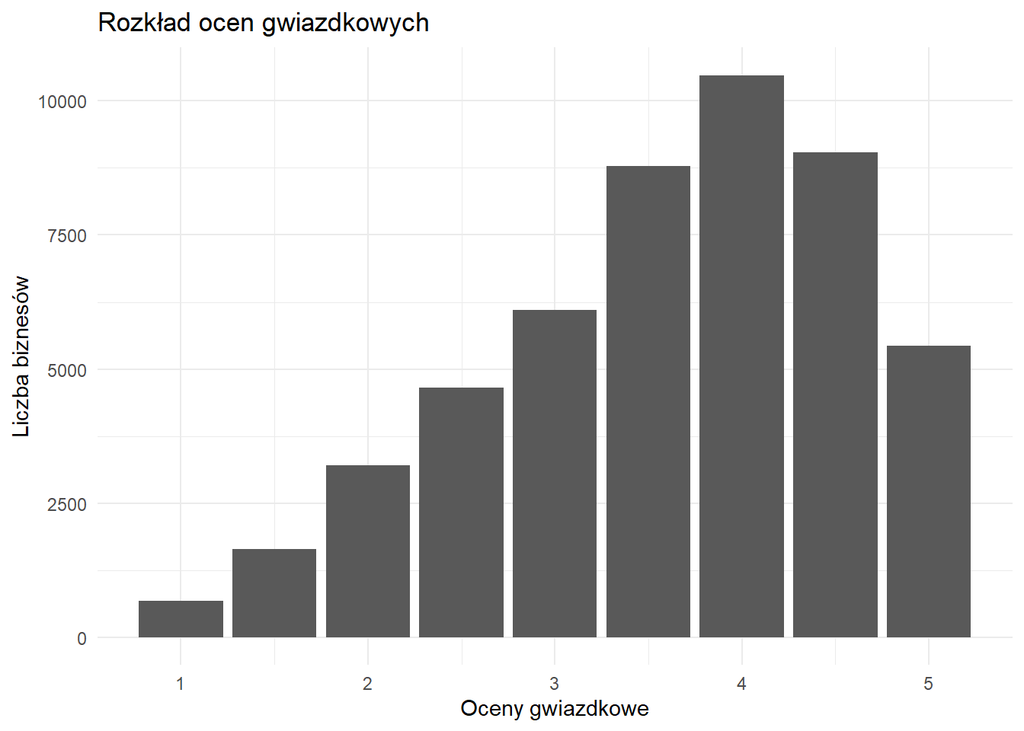

```r
x <- business %>%
  count(stars, name = "count") %>%
  arrange(stars)

ggplot(x, aes(x = stars, y = count)) +
  geom_col() +
  labs(
    title = "Rozkład ocen gwiazdkowych",
    x = "Oceny gwiazdkowe",
    y = "Liczba biznesów"
  ) +
  theme_minimal()
```

Wykres przedstawia rozkład średnich ocen gwiazdkowych dla biznesów dostępnych w zbiorze Yelp. Zauważalna jest koncentracja ocen w przedziale 3–4 gwiazdek, co sugeruje, że większość biznesów otrzymuje umiarkowanie pozytywne oceny, a skrajnie niskie i skrajnie wysokie oceny występują rzadziej. Można tu zauważyć stosunkowo silny bias w kierunku ocen pozytywnych. Z praktycznego punktu widzenia, biznesy dążą do uzyskania ocen w górnym zakresie skali, a dodatkowo można założyć, że przedsiębiorstwa z bardzo niskimi ocenami mogą być bardziej podatne na upadek - tracą na ważności

### 7.2 Topowe kategorie biznesów

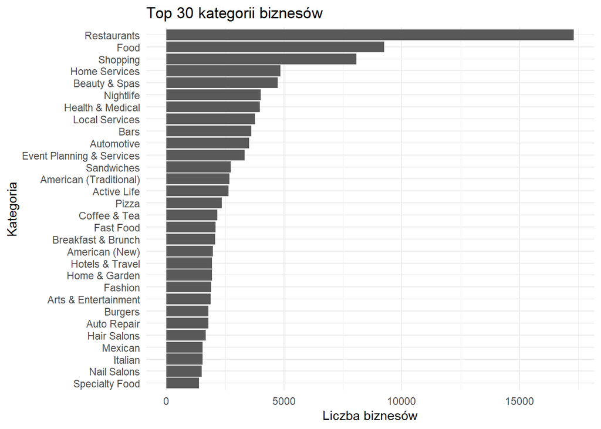

```r
cats <- business %>%
  filter(!is.na(categories)) %>%
  mutate(category = str_split(categories, ",\\s*")) %>%
  tidyr::unnest(category) %>%
  count(category, sort = TRUE)

top_n <- 30
cats_top <- cats %>% slice_head(n = top_n)

ggplot(cats_top, aes(x = reorder(category, n), y = n)) +
  geom_col() +
  coord_flip() +
  labs(
    title = paste0("Top ", top_n, " kategorii biznesów"),
    x = "Kategoria",
    y = "Liczba biznesów"
  ) +
  theme_minimal()
```

Dominują kategorie powiązane z usługami lokalnymi i gastronomią. Warto pamiętać, że jeden biznes może mieć przypisanych wiele kategorii.

## 8 Analiza sentymentu (Hugging Face Inference API)

### 8.1 Funkcje API + analiza próbki

```r
hf_text_classification <- function(text, model_name, token) {
  url <- paste0("https://router.huggingface.co/hf-inference/models/", model_name)

  req <- request(url) |>
    req_headers(
      Authorization = paste("Bearer", token),
      `Content-Type` = "application/json"
    ) |>
    req_body_json(list(inputs = text), auto_unbox = TRUE) |>
    req_error(is_error = function(resp) FALSE)

  resp <- req_perform(req)

  resp_body_json(resp, simplifyVector = FALSE)
}

pick_best_label <- function(result) {
  classes <- result[[1]]

  classes <- Filter(function(x) !is.null(x[["label"]]) && !is.null(x[["score"]]), classes)

  scores <- vapply(classes, function(x) as.numeric(x[["score"]]), numeric(1))
  best_i <- which.max(scores)

  list(
    label = classes[[best_i]][["label"]],
    score = classes[[best_i]][["score"]]
  )
}

analyze_reviews <- function(df, limit, seed, model_name, token) {
  set.seed(seed)
  n <- min(limit, nrow(df))
  sample_df <- df %>% slice_sample(n = n)

  results <- vector("list", n)

  for (i in seq_len(n)) {
    txt <- as.character(sample_df$text[i])

    # shortening the text, so API doesnt error out
    txt <- substr(txt, 1, 2000)

    res <- hf_text_classification(txt, model_name, token)
    best <- pick_best_label(res)

    results[[i]] <- list(
      hf_label = best$label,
      hf_score = best$score
    )

    if (i %% 25 == 0) message("Przetworzono: ", i, " / ", n)
  }

  bind_cols(sample_df, bind_rows(results))
}
```

```r
analyzed <- analyze_reviews(
  df = reviews,
  limit = ANALYZE_LIMIT,
  seed = RANDOM_STATE,
  model_name = MODEL_NAME,
  token = HF_TOKEN
)

head(analyzed[, c("stars", "hf_label", "hf_score")])
```

```
## # A tibble: 6 × 3
##   stars hf_label hf_score
##   <dbl> <chr>       <dbl>
## 1     5 positive    0.976
## 2     5 positive    0.966
## 3     5 positive    0.974
## 4     5 positive    0.985
## 5     5 positive    0.987
## 6     1 negative    0.623
```

### 8.2 Dystrybucja sentymentu względem ocen gwiazdkowych

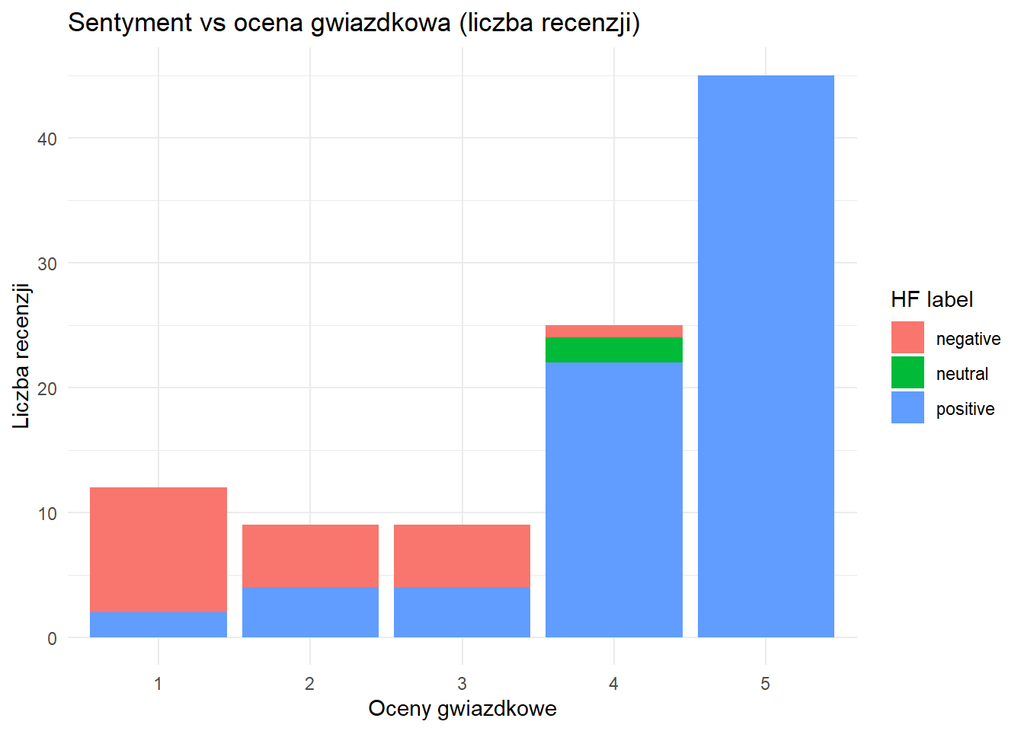

```r
pivot <- analyzed %>%
  filter(!is.na(stars)) %>%
  count(stars, hf_label, name = "count") %>%
  tidyr::pivot_wider(names_from = hf_label, values_from = count, values_fill = 0) %>%
  arrange(stars)

pivot_long <- pivot %>%
  tidyr::pivot_longer(-stars, names_to = "hf_label", values_to = "count")

ggplot(pivot_long, aes(x = factor(stars), y = count, fill = hf_label)) +
  geom_col() +
  labs(
    title = "Sentyment vs ocena gwiazdkowa (liczba recenzji)",
    x = "Oceny gwiazdkowe",
    y = "Liczba recenzji",
    fill = "HF label"
  ) +
  theme_minimal()
```

Wykres pokazuje zależność pomiędzy oceną gwiazdkową a sentymentem treści recenzji. Widoczny jest wyraźny trend: wraz ze wzrostem liczby gwiazdek rośnie udział sentymentu pozytywnego, natomiast maleje udział sentymentu negatywnego.

Dodatkowo można zauważyć, że model w większości wypadków wykazuje się wysoką pewnością klasyfikacji, co sugeruje, że istnieją wyraźne sygnały sentymentalne zgodne z wskazujące na oceny gwiazdkowe.

### 8.3 Rozkład ocen gwiazdkowych w analizowanej próbie

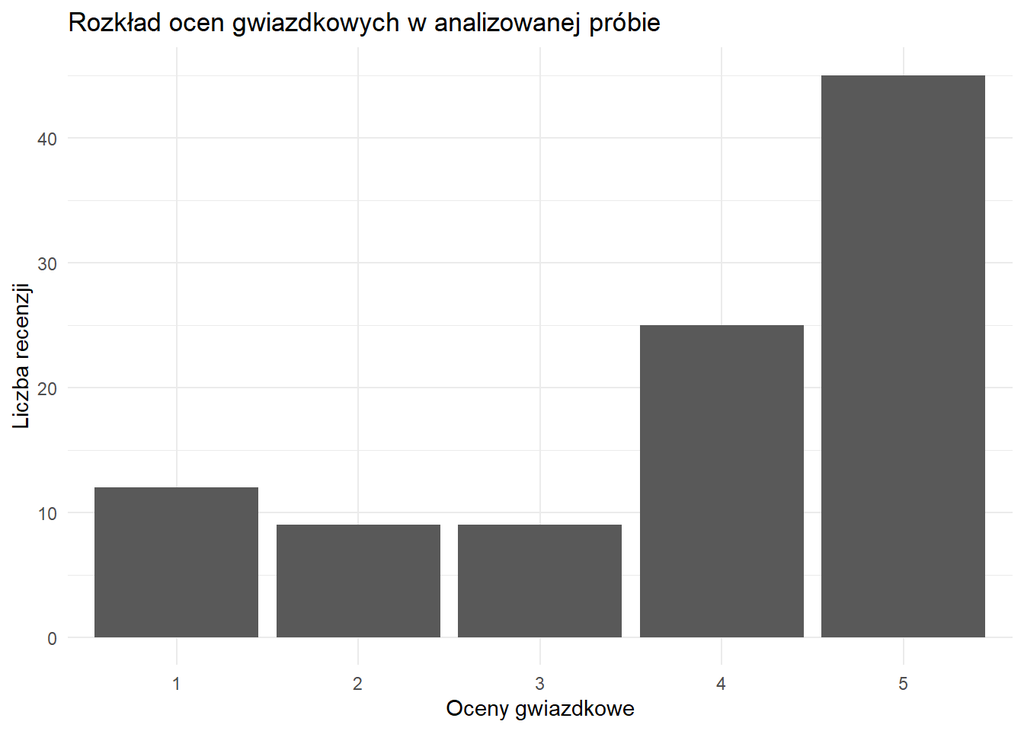

```r
counts <- analyzed %>% count(stars, name = "count") %>% arrange(stars)

ggplot(counts, aes(x = factor(stars), y = count)) +
  geom_col() +
  labs(
    title = "Rozkład ocen gwiazdkowych w analizowanej próbie",
    x = "Oceny gwiazdkowe",
    y = "Liczba recenzji"
  ) +
  theme_minimal()
```

## 9 Wnioski

> Ze względu na losowy dobór próby oraz ograniczoną liczbę analizowanych recenzji, wnioski mają charakter eksploracyjny i dotyczą analizowanej próbki danych.